# Q.1 DOMAIN: Botanical research

## CONTEXT:

University X is currently undergoing some research involving understanding the characteristics of plant and plant seedlings at various stages of growth. They already have have invested on curating sample images. They require an automation which can create a classifier capable of determining a plant's species from a photo

## DATA DESCRIPTION:

The dataset comprises of images from 12 plant species. Source: https://www.kaggle.com/c/plant-seedlings-classification/data

## PROJECT OBJECTIVE:

University’s management require an automation which can create a classifier capable of determining a plant's species from a photo

## Steps and tasks: [ Total Score: 20 points]

1. Import the data. Analyse the dimensions of the data. Visualise the data.
2. Train tune and test AIML image classifier model using: • Use supervised learning algorithms for training • Use neural networks for training • Use CNN for training
3. Compare the results from the above step along with your detailed observations.
4. Pickle the best performing model.
5. Import the the image in the “ Prediction” folder to predict the class. Display the image. Use the best trained image classifier model to predict the class

```python
import tensorflow as tf
tf.__version__

import random
random.seed(0)

import warnings
warnings.filterwarnings('ignore')

import matplotlib.pyplot as plt
%matplotlib inline
import numpy as np
from tqdm import tqdm
import pandas as pd
```

```python
device_name = tf.test.gpu_device_name()
if device_name != '/device:GPU:0':
  raise SystemError('GPU device not found')
print('Found GPU at: {}'.format(device_name))
```

```
Found GPU at: /device:GPU:0
```

## 1. Import the data. Analyse the dimensions of the data. Visualise the data.

### a) Import the data

```python
from google.colab import drive
drive.mount('/content/gdrive')
project_path = '/content/gdrive/MyDrive/Colab/Computer Vision/CNN-Plant-Seedlings-dataset/Plant Seedling Classification Data/'  #Destination path where the dataset will be downloaded
```

```python
import os
os.getcwd()
# CHange directory to the project path
os.chdir(project_path)
os.getcwd()
```

```
'/content/gdrive/.shortcut-targets-by-id/10Pk9PMfUOAPI3yTYZ6nvtwBA1CXRC9MG/Plant Seedling Classification Data'
```

### b) Analyse the dimensions of the data

```python
# checking dimensions of a test image
from PIL import Image
import cv2
import numpy as np
IMAGE_SIZE = 128  # Target image size for training and evaluation

test_image_path = project_path+'test/0a64e3e6c.png'
test_image = cv2.imread(test_image_path)
print('Original size of the test_image: ', test_image.shape)
# test_image = cv2.resize(test_image, (IMAGE_SIZE, IMAGE_SIZE))
# print('Size after resize: ', test_image.shape)
# test_image = np.expand_dims(test_image,axis=0)
# test_image = test_image*1/255.0
# print('After Expanded dims, size of test_image: ', test_image.shape)
```

```
Original size of the test_image:  (237, 237, 3)
```

#### Image Data Augmentation for Deep Learning and CNN

```python
# Image augmentation
train_path = project_path + 'train/'
train_datagen = ImageDataGenerator(
        rescale=1./255,
        shear_range=0.2,
        zoom_range=0.2,
        horizontal_flip=True, vertical_flip=True,
        validation_split=0.2)
validation_datagen = ImageDataGenerator(rescale=1./255, validation_split=0.2)
train_generator = train_datagen.flow_from_directory(
        train_path,
        target_size=(IMAGE_SIZE, IMAGE_SIZE),
        batch_size=32,
        class_mode='categorical', subset='training' )
validation_generator = validation_datagen.flow_from_directory(
        train_path,
        target_size=(IMAGE_SIZE, IMAGE_SIZE),
        batch_size=32,
        class_mode='categorical', subset='validation', shuffle=False)
```

```
Found 3816 images belonging to 12 classes.
Found 951 images belonging to 12 classes.
```

```python
train_count = train_generator.samples
print('Number of training Batches: ',int(train_count/32))
```

```
Number of training Batches:  119
```

```python
val_count = validation_generator.samples
print('Number of validation Batches: ',int(val_count/32))
```

```
Number of validation Batches:  29
```

```python
# Store the data in X_train, y_train variables by iterating over the batches
train_generator.reset()
X_train, y_train = next(train_generator)
for i in tqdm(range(int(train_count/32)-1)):
  img, label = next(train_generator)
  X_train = np.append(X_train, img, axis=0 )
  y_train = np.append(y_train, label, axis=0)
print(X_train.shape, y_train.shape)
```

```
(3808, 128, 128, 3) (3808, 12)
```

```python
# Store the data in X_val, y_val variables by iterating over the batches
validation_generator.reset()
X_val, y_val = next(validation_generator)
for i in tqdm(range(int(val_count/32)-1)):
  img, label = next(validation_generator)
  X_val = np.append(X_val, img, axis=0 )
  y_val = np.append(y_val, label, axis=0)
print(X_val.shape, y_val.shape)
```

```
(928, 128, 128, 3) (928, 12)
```

```python
print(X_train.shape, y_train.shape, X_val.shape, y_val.shape)
```

```
(3808, 128, 128, 3) (3808, 12) (928, 128, 128, 3) (928, 12)
```

```python
seedlings_dict = train_generator.class_indices
print('Available classes: ', seedlings_dict)
seedlings_dict.values
a = list(seedlings_dict.items())
seedlings_np = np.array(a)
seedlings = seedlings_np[:,0]
print('\n After converting the dictionary into simple array: \n', seedlings)
print('\n Referencing a class with index: ', seedlings[10])
```

```
Available classes:  {'Black-grass': 0, 'Charlock': 1, 'Cleavers': 2, 'Common Chickweed': 3, 'Common wheat': 4, 'Fat Hen': 5, 'Loose Silky-bent': 6, 'Maize': 7, 'Scentless Mayweed': 8, 'Shepherds Purse': 9, 'Small-flowered Cranesbill': 10, 'Sugar beet': 11}

 After converting the dictionary into simple array:
 ['Black-grass' 'Charlock' 'Cleavers' 'Common Chickweed' 'Common wheat'
 'Fat Hen' 'Loose Silky-bent' 'Maize' 'Scentless Mayweed'
 'Shepherds Purse' 'Small-flowered Cranesbill' 'Sugar beet']

 Referencing a class with index:  Small-flowered Cranesbill
```

### c) Visualize the data

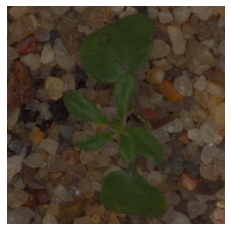

```
Cleavers
```

```python
#Visualize one image
plt.subplots(1)
img = Image.open(project_path + 'train/Cleavers/0a1e622bc.png')
plt.imshow(img)
plt.axis('off')
plt.show()
print(seedlings[2])
```

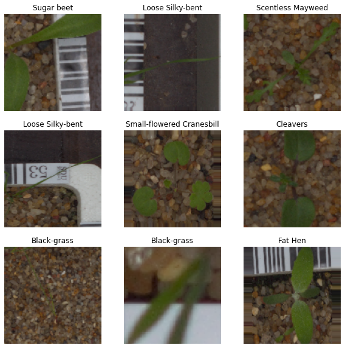

```python
# Visualize some random 9 images from the train_data batch dataset
train_generator.reset()
image_batch, label_batch = next(train_generator)
plt.figure(figsize=(10,10))
for i in range(9):
  ax = plt.subplot(3,3, i+1)
  plt.imshow(image_batch[i])
  label = label_batch[i].astype('uint8')
  #print(label.argmax())
  plt.title(seedlings[label.argmax()])
  #print(label)
  plt.axis('off')
```

## 2. Train tune and test AIML image classifier model using:

1. Use supervised learning algorithms for training
2. Use neural networks for training
3. Use CNN for training

### 0. Preprocess the data first

```python
# Flatten the images for SVM
X_train_flat = X_train.reshape(X_train.shape[0], IMAGE_SIZE*IMAGE_SIZE*3)
X_train_flat.shape
```

```
(3808, 49152)
```

```python
# Function to convert y variable into categorical labeled data
def f(x):
    return seedlings[x.argmax()]
```

```python
y_train_flat = np.array(list(map(f,y_train)))
y_train_flat[10]
```

```
'Sugar beet'
```

```python
print(y_train_flat.shape)
print(np.unique(y_train_flat))
```

```
(3808,)
['Black-grass' 'Charlock' 'Cleavers' 'Common Chickweed' 'Common wheat'
 'Fat Hen' 'Loose Silky-bent' 'Maize' 'Scentless Mayweed'
 'Shepherds Purse' 'Small-flowered Cranesbill' 'Sugar beet']
```

```python
#Similarly for Validation Data
X_val_flat = X_val.reshape(X_val.shape[0], IMAGE_SIZE*IMAGE_SIZE*3)
y_val_flat = np.array(list(map(f,y_val)))
print(X_val_flat.shape, y_val_flat.shape)
```

```
(928, 49152) (928,)
```

### 1. Supervised Learning: SVM

```python
from sklearn.svm import SVC
from sklearn.metrics import classification_report
svc = SVC()
device_name = tf.test.gpu_device_name()
if device_name != '/device:GPU:0':
  print(
      '\n\nThis error most likely means that this notebook is not '
      'configured to use a GPU.  Change this in Notebook Settings via the '
      'command palette (cmd/ctrl-shift-P) or the Edit menu.\n\n')
  raise SystemError('GPU device not found')

with tf.device('/device:GPU:0'):
  svc.fit( X_train_flat, y_train_flat)
```

```python
with tf.device('/device:GPU:0'):
  svc_score = svc.score(X_val_flat, y_val_flat)
print(svc_score)
```

```
0.4525862068965517
```

```python
y_pred_svc = svc.predict(X_val_flat)
print(classification_report(y_val_flat, y_pred_svc))
```

```
                           precision    recall  f1-score   support

              Black-grass       0.17      0.02      0.03        52
                 Charlock       0.59      0.50      0.54        78
                 Cleavers       0.50      0.53      0.51        57
         Common Chickweed       0.42      0.61      0.50       122
             Common wheat       0.00      0.00      0.00        44
                  Fat Hen       0.40      0.22      0.28        95
         Loose Silky-bent       0.39      0.88      0.54       134
                    Maize       1.00      0.18      0.31        44
        Scentless Mayweed       0.48      0.42      0.45       103
          Shepherds Purse       0.00      0.00      0.00        46
Small-flowered Cranesbill       0.64      0.66      0.65        99
               Sugar beet       0.32      0.37      0.34        54

                 accuracy                           0.45       928
                macro avg       0.41      0.37      0.35       928
             weighted avg       0.43      0.45      0.40       928
```

### 2. Deep Learning

```python
from tensorflow.keras.models import Sequential
from tensorflow.keras.layers import Dense, BatchNormalization, Flatten, Dropout
from tensorflow.keras.optimizers import Adam
from tensorflow.keras.callbacks import Callback, EarlyStopping, ModelCheckpoint
from tensorflow.keras.preprocessing.image import ImageDataGenerator
```

```python
model = Sequential()
model.add(Flatten())
model.add(BatchNormalization())
model.add(Dense(128, input_shape=X_train[0].shape, activation='relu'))
model.add(Dropout(0.4))

model.add(BatchNormalization())
model.add(Dense(64, activation='relu'))
model.add(Dropout(0.4))

# model.add(Dense(64, activation='relu'))
# model.add(BatchNormalization())
# model.add(Dropout(0.2))

#model.add(Flatten())
model.add(Dense(12, activation='softmax'))
```

```python
print(X_train.shape, y_train.shape, X_val.shape, y_val.shape)
```

[output not shown]

```python
# Add Callbacks to pick the best model parameters
earlystop = EarlyStopping(monitor='val_loss', min_delta=0.01, patience=3, restore_best_weights=True)
checkpoint = ModelCheckpoint(filepath ='/tmp/checkpoint', monitor='val_loss', mode='min', save_best_only=True, verbose=1)

adam_opt = Adam(learning_rate=0.01, beta_1=0.9, beta_2=0.999, amsgrad=True)
model.compile(adam_opt, loss='categorical_crossentropy', metrics=['accuracy', tf.keras.metrics.Precision(), tf.keras.metrics.Recall()])
```

```python
with tf.device('/device:GPU:0'):
  model.fit_generator(train_generator, validation_data=validation_generator, steps_per_epoch=int(len(X_train)/32), epochs=50, callbacks=[earlystop, checkpoint])
```

```
Epoch 00001: val_loss improved from inf to 2.26189, saving model to /tmp/checkpoint
INFO:tensorflow:Assets written to: /tmp/checkpoint/assets

Epoch 00002: val_loss improved from 2.26189 to 2.21816, saving model to /tmp/checkpoint
INFO:tensorflow:Assets written to: /tmp/checkpoint/assets

Epoch 00003: val_loss improved from 2.21816 to 1.81725, saving model to /tmp/checkpoint
INFO:tensorflow:Assets written to: /tmp/checkpoint/assets

Epoch 00004: val_loss improved from 1.81725 to 1.67123, saving model to /tmp/checkpoint
INFO:tensorflow:Assets written to: /tmp/checkpoint/assets

Epoch 00005: val_loss improved from 1.67123 to 1.49693, saving model to /tmp/checkpoint
INFO:tensorflow:Assets written to: /tmp/checkpoint/assets

Epoch 00006: val_loss did not improve from 1.49693

Epoch 00007: val_loss improved from 1.49693 to 1.45818, saving model to /tmp/checkpoint
INFO:tensorflow:Assets written to: /tmp/checkpoint/assets

Epoch 00008: val_loss did not improve from 1.45818

Epoch 00009: val_loss improved from 1.45818 to 1.38576, saving model to /tmp/checkpoint
INFO:tensorflow:Assets written to: /tmp/checkpoint/assets

Epoch 00010: val_loss did not improve from 1.38576

Epoch 00011: val_loss improved from 1.38576 to 1.33676, saving model to /tmp/checkpoint
INFO:tensorflow:Assets written to: /tmp/checkpoint/assets

Epoch 00012: val_loss did not improve from 1.33676

Epoch 00013: val_loss did not improve from 1.33676

Epoch 00014: val_loss improved from 1.33676 to 1.31952, saving model to /tmp/checkpoint
INFO:tensorflow:Assets written to: /tmp/checkpoint/assets

Epoch 00015: val_loss did not improve from 1.31952

Epoch 00016: val_loss improved from 1.31952 to 1.30002, saving model to /tmp/checkpoint
INFO:tensorflow:Assets written to: /tmp/checkpoint/assets

Epoch 00017: val_loss did not improve from 1.30002

Epoch 00018: val_loss did not improve from 1.30002

Epoch 00019: val_loss did not improve from 1.30002
```

```python
model.evaluate(validation_generator)
```

```
[1.300018072128296, 0.5617740154266357, 0.7761194109916687, 0.2745512127876282]
```

```python
model.summary()
```

```
Model: "sequential_4"
_________________________________________________________________
Layer (type)                 Output Shape              Param #
=================================================================
flatten_4 (Flatten)          (None, None)              0
_________________________________________________________________
batch_normalization_8 (Batch (None, 49152)             196608
_________________________________________________________________
dense_12 (Dense)             (None, 128)               6291584
_________________________________________________________________
dropout_8 (Dropout)          (None, 128)               0
_________________________________________________________________
batch_normalization_9 (Batch (None, 128)               512
_________________________________________________________________
dense_13 (Dense)             (None, 64)                8256
_________________________________________________________________
dropout_9 (Dropout)          (None, 64)                0
_________________________________________________________________
dense_14 (Dense)             (None, 12)                780
=================================================================
Total params: 6,497,740
Trainable params: 6,399,180
Non-trainable params: 98,560
_________________________________________________________________
```

### 3. Convolution Neural Networks (CNN)

```python
from tensorflow.keras.layers import Conv2D, MaxPooling2D, Activation
from tensorflow.keras.optimizers import Adam
from tensorflow.keras.models import Sequential
from tensorflow.keras.layers import Dense, BatchNormalization, Flatten, Dropout
from tensorflow.keras.callbacks import Callback, EarlyStopping, ModelCheckpoint
```

```python
conv = Sequential()
conv.add(Conv2D(16, (3,3), padding='same', input_shape=X_train.shape[1:], activation='relu'))
conv.add(BatchNormalization())
conv.add(Conv2D(32, (3,3), padding='same', activation='relu'))
conv.add(BatchNormalization())
conv.add(MaxPooling2D(pool_size=(2,2)))
conv.add(Dropout(0.3))

conv.add(Conv2D(32, (3,3), padding='same', activation='relu'))
conv.add(BatchNormalization())
conv.add(Conv2D(32, (3,3), padding='same', activation='relu'))
conv.add(BatchNormalization())
conv.add(MaxPooling2D(pool_size=(2,2)))
conv.add(Dropout(0.3))

# conv.add(Conv2D(32, (3,3), padding='same', activation='relu'))
# conv.add(BatchNormalization())
# conv.add(MaxPooling2D(pool_size=(2,2)))
# conv.add(Dropout(0.3))

# conv.add(Conv2D(64, (3,3), padding='same', activation='relu'))
# conv.add(BatchNormalization())
# conv.add(Dropout(0.2))

conv.add(Flatten())
conv.add(Dense(12))
conv.add(Activation('softmax'))
```

```python
# Add Callbacks to pick the best model parameters
earlystop = EarlyStopping(monitor='val_loss', min_delta=0.001, patience=5, restore_best_weights=True)
checkpoint = ModelCheckpoint(filepath ='/tmp/checkpoint', monitor='val_loss', mode='min', save_best_only=True, verbose=1)
adam_opt = Adam(learning_rate=0.001, beta_1=0.9, beta_2=0.999, amsgrad=True)
conv.compile(adam_opt, loss='categorical_crossentropy', metrics=['accuracy', tf.keras.metrics.Precision(), tf.keras.metrics.Recall()])
#conv.compile('sgd', loss='categorical_crossentropy', metrics=['accuracy', tf.keras.metrics.Precision(), tf.keras.metrics.Recall()])
```

```python
with tf.device('/device:GPU:0'):
  conv.fit( train_generator,
           validation_data=validation_generator,
           steps_per_epoch = len(X_train)/32, epochs=50, callbacks=[earlystop, checkpoint])
```

[output not shown]

[output cut: 40 more lines]

```

Epoch 00035: val_loss did not improve from 0.68427

Epoch 00036: val_loss improved from 0.68427 to 0.60928, saving model to /tmp/checkpoint
INFO:tensorflow:Assets written to: /tmp/checkpoint/assets

Epoch 00037: val_loss did not improve from 0.60928

Epoch 00038: val_loss did not improve from 0.60928

Epoch 00039: val_loss did not improve from 0.60928

Epoch 00040: val_loss did not improve from 0.60928

Epoch 00041: val_loss did not improve from 0.60928
```

```python
conv.evaluate(validation_generator)
```

```
[0.6092838048934937, 0.890641450881958, 0.8961864113807678, 0.8895899057388306]
```

```python
conv.summary()
```

```
Model: "sequential_5"
_________________________________________________________________
Layer (type)                 Output Shape              Param #
=================================================================
conv2d_97 (Conv2D)           (None, 128, 128, 16)      448
_________________________________________________________________
batch_normalization_109 (Bat (None, 128, 128, 16)      64
_________________________________________________________________
conv2d_98 (Conv2D)           (None, 128, 128, 32)      4640
_________________________________________________________________
batch_normalization_110 (Bat (None, 128, 128, 32)      128
_________________________________________________________________
max_pooling2d_6 (MaxPooling2 (None, 64, 64, 32)        0
_________________________________________________________________
dropout_7 (Dropout)          (None, 64, 64, 32)        0
_________________________________________________________________
conv2d_99 (Conv2D)           (None, 64, 64, 32)        9248
_________________________________________________________________
batch_normalization_111 (Bat (None, 64, 64, 32)        128
_________________________________________________________________
conv2d_100 (Conv2D)          (None, 64, 64, 32)        9248
_________________________________________________________________
batch_normalization_112 (Bat (None, 64, 64, 32)        128
_________________________________________________________________
max_pooling2d_7 (MaxPooling2 (None, 32, 32, 32)        0
_________________________________________________________________
dropout_8 (Dropout)          (None, 32, 32, 32)        0
_________________________________________________________________
flatten_5 (Flatten)          (None, 32768)             0
_________________________________________________________________
dense_14 (Dense)             (None, 12)                393228
_________________________________________________________________
activation_98 (Activation)   (None, 12)                0
=================================================================
Total params: 417,260
Trainable params: 417,036
Non-trainable params: 224
_________________________________________________________________
```